# Peer Review Assignment 1

Md Sabbirul Haque

January 24, 2019

# Loading and preprocessing the data

#### 1. Code for reading in the dataset and/or processing the data

```r
rm(list=ls())
fileUrl <- "https://d396qusza40orc.cloudfront.net/repdata%2Fdata%2Factivity.zip"
download.file(fileUrl, destfile = paste0(getwd(), '/zipped_data_folder.zip'))
unzip("zipped_data_folder.zip",exdir = "unziped_data_folder")
file<-list.files("unziped_data_folder", full.names = TRUE)
data<-read.csv(file)
```

# What is mean total number of steps taken per day?

#### 2. Histogram of the total number of steps taken each day

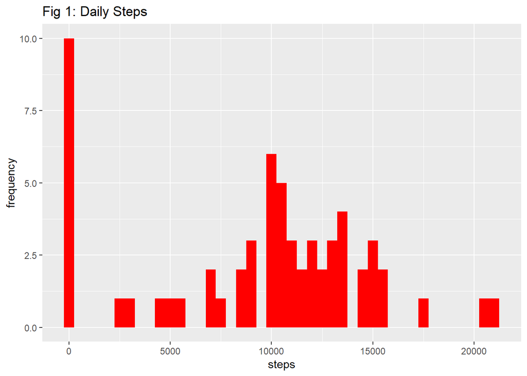

```r
total_steps<-data %>% group_by(date) %>% summarise(total=sum(steps, na.rm = TRUE)) %>% as.data.frame()
ggplot(total_steps, aes(x = total)) +
  geom_histogram(fill = "red", binwidth = 500) +
  labs(title = "Fig 1: Daily Steps", x = "steps", y = "frequency")
```

#### 3. Mean and median number of steps taken each day

Mean and median of total number of steps taken per day are 9354.2295082 and 10395 respectively.

# What is the average daily activity pattern?

#### 4. Time series plot of the average number of steps taken

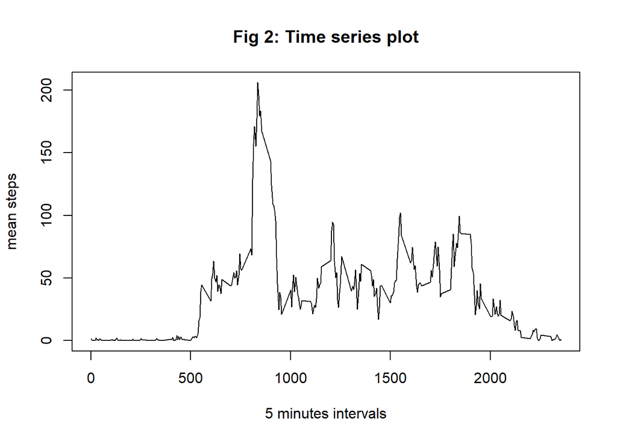

```r
total_steps<-data %>% group_by(interval) %>% summarise(total=sum(steps, na.rm = TRUE), avg=mean(steps, na.rm = TRUE)) %>% as.data.frame()

plot(total_steps$interval, total_steps$avg, type= "l", xlab="5 minutes intervals", ylab="mean steps", main = "Fig 2: Time series plot")
```

#### 5. The 5-minute interval that, on average, contains the maximum number of steps

The 5-munites interval that, on average, contains the maximum number of steps is 835. This maximum value is 206.1698113.

# Imputing missing values

I replace the missing values by the median of numbers of steps for all days for the same interval.

#### 6. Code to describe and show a strategy for imputing missing data

```r
paste("Total number of missing values before imputing: ", sum(is.na(data$steps)))
```

```
## [1] "Total number of missing values before imputing:  2304"
```

```r
missing_index<-as.numeric(which(is.na(data$steps)))
new_data<-data
for(i in missing_index){
  new_data$steps[i]<-median(new_data$steps[new_data$interval==new_data$interval[i]], na.rm = TRUE)
  }
paste("Total number of missing values after imputing: ", sum(is.na(new_data$steps)))
```

```
## [1] "Total number of missing values after imputing:  0"
```

#### 7. What is mean total number of steps taken per day? Histogram of the total number of steps taken each day after missing values are imputed

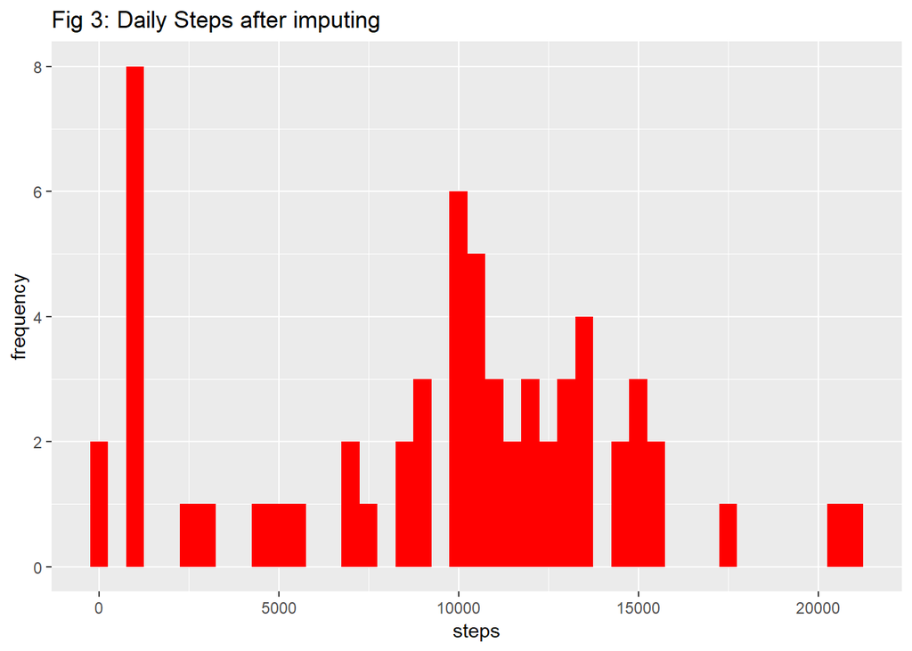

```r
new_total_steps<-new_data %>% group_by(date) %>% summarise(total=sum(steps, na.rm = TRUE)) %>% as.data.frame()

ggplot(new_total_steps, aes(x = total)) +
  geom_histogram(fill = "red", binwidth = 500) +
  labs(title = "Fig 3: Daily Steps after imputing", x = "steps", y = "frequency")
```

```r
paste("daily mean   (after imputing) =", mean(new_total_steps$total, na.rm = TRUE))
```

```
## [1] "daily mean   (after imputing) = 9503.86885245902"
```

```r
paste("daily median (after imputing)=", median(new_total_steps$total, na.rm = TRUE))
```

```
## [1] "daily median (after imputing)= 10395"
```

# Are there differences in activity patterns between weekdays and weekends?

#### 8. Panel plot comparing the average number of steps taken per 5-minute interval across weekdays and weekends

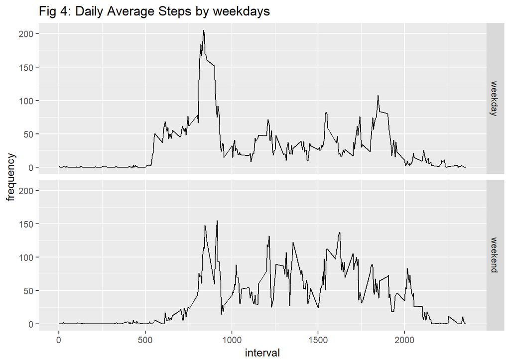

```r
week_days<-c("Monday", "Tuesday", "Wednesday", "Thursday", "Friday")
new_data$day<-as.factor(ifelse(weekdays(ymd(new_data$date)) %in% week_days, "weekday", "weekend"))

new_data_weekday <-new_data %>% filter(day=="weekday") %>% group_by(interval) %>%
  summarise(avg=mean(steps, na.rm = TRUE)) %>% as.data.frame()%>%   mutate(day="weekday")

new_data_weekend <-new_data %>% filter(day=="weekend") %>% group_by(interval) %>%
  summarise(avg=mean(steps, na.rm = TRUE)) %>% as.data.frame()%>% mutate(day="weekend")

combined_new_data<-bind_rows(new_data_weekday, new_data_weekend)
combined_new_data$day<-as.factor(combined_new_data$day)

combined_new_data %>% ggplot(aes(interval, avg))+geom_line()+
  labs(title = "Fig 4: Daily Average Steps by weekdays", x = "interval", y = "frequency")+facet_grid(day ~.)
```

Comparing weekend and weekday activity paterns, in general, the weekend activity tends to be more symmetric and spread over interval whereas for the weekdays the activity seems to be more skewed to the left.